# Final term Project - MLD

February 26, 2019

# 1 Goal of the EDA:

The goal of this EDA is to understand what is the effect of minorities and racial/ethenic groups on mortgage lending , and to coclude the finding.

# 2 Prerequisites for analysis

Following needs to be prior to any analysis:

- Clear your environment
- Load required packages
- Organize your work and point to the right directories

Following needs to be done prior to starting an EDA:

- Load raw data
- Make changes to data based on business rules definitions
- Perform joins as required

```r
mld_data <- raw_data %>%
  rename(cred_meet = GDLIN, other_oblg = OBRAT) %>%
              mutate( MARRIED = factor(MARRIED),
                      cred_meet = factor(cred_meet),
                      BLACK = factor(BLACK),
                      HISPAN = factor(HISPAN),
                      MALE = factor(MALE),
                      APPROVE = factor(APPROVE))

str(mld_data)
```

```
## Classes 'tbl_df', 'tbl' and 'data.frame':    1989 obs. of  8 variables:
##  $ MARRIED   : Factor w/ 3 levels ".","0","1": 2 3 2 3 3 2 2 2 3 3 ...
##  $ cred_meet : Factor w/ 3 levels "0","1","666": 2 2 2 2 2 2 2 2 2 2 ...
##  $ other_oblg: num  34.5 34.1 26 37 32.1 33 36 37 30.7 49 ...
##  $ BLACK     : Factor w/ 2 levels "0","1": 1 1 1 1 1 1 1 1 1 1 ...
##  $ HISPAN    : Factor w/ 2 levels "0","1": 1 1 1 1 1 1 1 1 1 1 ...
##  $ MALE      : Factor w/ 3 levels ".","0","1": 1 3 3 3 3 3 3 3 3 3 ...
##  $ APPROVE   : Factor w/ 2 levels "0","1": 2 1 2 2 2 2 2 2 2 2 ...
##  $ LOANPRC   : num  0.754 0.8 0.895 0.6 0.896 ...
```

# 3 Summary of data

We look at a summary of data:

- to know how clean the data is
- to check if typical values (in the middle or at extremes) make sense
- to confirm if there missing values that need to be addressed

The **skim** function in the **skimr** package summarises columns separately by data type - (here) factor variables followed by integers and numerics

```r
panderOptions('table.split.table', Inf)
skim(mld_data) %>% pander()
```

Skim summary statistics  
n obs: 1989  
n variables: 8

| variable | missing | complete | n | n_unique | top_counts | ordered |
| --- | --- | --- | --- | --- | --- | --- |
| APPROVE | 0 | 1989 | 1989 | 2 | 1: 1745, 0: 244, NA: 0 | FALSE |
| BLACK | 0 | 1989 | 1989 | 2 | 0: 1792, 1: 197, NA: 0 | FALSE |
| cred_meet | 0 | 1989 | 1989 | 3 | 1: 1816, 0: 171, 666: 2, NA: 0 | FALSE |
| HISPAN | 0 | 1989 | 1989 | 2 | 0: 1878, 1: 111, NA: 0 | FALSE |
| MALE | 0 | 1989 | 1989 | 3 | 1: 1605, 0: 369, .: 15, NA: 0 | FALSE |
| MARRIED | 0 | 1989 | 1989 | 3 | 1: 1308, 0: 678, .: 3, NA: 0 | FALSE |

| variable | missing | complete | n | mean | sd | p0 | p25 | p50 | p75 | p100 |
| --- | --- | --- | --- | --- | --- | --- | --- | --- | --- | --- |
| LOANPRC | 0 | 1989 | 1989 | 0.77 | 0.19 | 0.021 | 0.7 | 0.8 | 0.9 | 2.57 |
| other_oblg | 0 | 1989 | 1989 | 32.39 | 8.26 | 0 | 28 | 33 | 37 | 95 |

**Conclusions**:

- There are 1989 records with no missing values
- Majority of loans are approved
- Most people are not black
- Mostly people credit conditions are met
- Almost all loan applicants are non-hispanic
- Male applicants are male
- Majority of people applying for loan are married
- We have false data in dataset:
- Credit meet has a value (666) for 2 records
- Male and married have 15 and 3 observations with value (.)

# 4 Exploratory Data Analysis (Basic)

# 5 ## Univariate non-graphical – Categorical

```r
# Inspect descriptive statistics of data
summary(mld_data)
```

```
##  MARRIED  cred_meet    other_oblg    BLACK    HISPAN   MALE     APPROVE
##  .:   3   0  : 171   Min.   : 0.00   0:1792   0:1878   .:  15   0: 244
##  0: 678   1  :1816   1st Qu.:28.00   1: 197   1: 111   0: 369   1:1745
##  1:1308   666:   2   Median :33.00                     1:1605
##                      Mean   :32.39
##                      3rd Qu.:37.00
##                      Max.   :95.00
##     LOANPRC
##  Min.   :0.02105
##  1st Qu.:0.70000
##  Median :0.80000
##  Mean   :0.77064
##  3rd Qu.:0.89894
##  Max.   :2.57143
```

**Conclusions:**

- Other obligation has min - 0.0 and maximum percentage value as - 95%
- Loan Approval price has min amount - 0.02105 and maximum amount is - 2.57143. What is the unit here?

```r
# number of observations also proportion for Approval status
tabyl(mld_data$APPROVE) %>%
  adorn_pct_formatting() %>%
  kableExtra::kable(col.names = c("Approve", "Count", "Percent")) %>%
  kable_styling(full_width = FALSE)
```

| Approve | Count | Percent |
| --- | --- | --- |
| 0 | 244 | 12.3% |
| 1 | 1745 | 87.7% |

```r
# number of observations also proportion for Black applicant
tabyl(mld_data$BLACK) %>%
  adorn_pct_formatting() %>%
  kableExtra::kable(col.names = c("Black Applicants", "Count", "Percent")) %>%
  kable_styling(full_width = FALSE)
```

| Black Applicants | Count | Percent |
| --- | --- | --- |
| 0 | 1792 | 90.1% |
| 1 | 197 | 9.9% |

```r
# number of observations also proportion for Black applicant
tabyl(mld_data$cred_meet) %>%
  adorn_pct_formatting() %>%
  kableExtra::kable(col.names = c("Credit Cond Met", "Count", "Percent")) %>%
  kable_styling(full_width = FALSE)
```

| Credit Cond Met | Count | Percent |
| --- | --- | --- |
| 0 | 171 | 8.6% |
| 1 | 1816 | 91.3% |
| 666 | 2 | 0.1% |

```r
# number of observations also proportion for Black applicant
tabyl(mld_data$HISPAN) %>%
  adorn_pct_formatting() %>%
  kableExtra::kable(col.names = c("Hispanic Applicants", "Count", "Percent")) %>%
  kable_styling(full_width = FALSE)
```

| Hispanic Applicants | Count | Percent |
| --- | --- | --- |
| 0 | 1878 | 94.4% |
| 1 | 111 | 5.6% |

```r
# number of observations also proportion for Black applicant
tabyl(mld_data$MALE) %>%
  adorn_pct_formatting() %>%
  kableExtra::kable(col.names = c("Male Applicants", "Count", "Percent")) %>%
  kable_styling(full_width = FALSE)
```

| Male Applicants | Count | Percent |
| --- | --- | --- |
| . | 15 | 0.8% |
| 0 | 369 | 18.6% |
| 1 | 1605 | 80.7% |

```r
# number of observations also proportion for Black applicant
tabyl(mld_data$MARRIED) %>%
  adorn_pct_formatting() %>%
  kableExtra::kable(col.names = c("Married Applicants", "Count", "Percent")) %>%
  kable_styling(full_width = FALSE)
```

| Married Applicants | Count | Percent |
| --- | --- | --- |
| . | 3 | 0.2% |
| 0 | 678 | 34.1% |
| 1 | 1308 | 65.8% |

# 6 ## Univariate graphical – Categorical

We need to look at frequencies of categorical variables to confirm the distribution

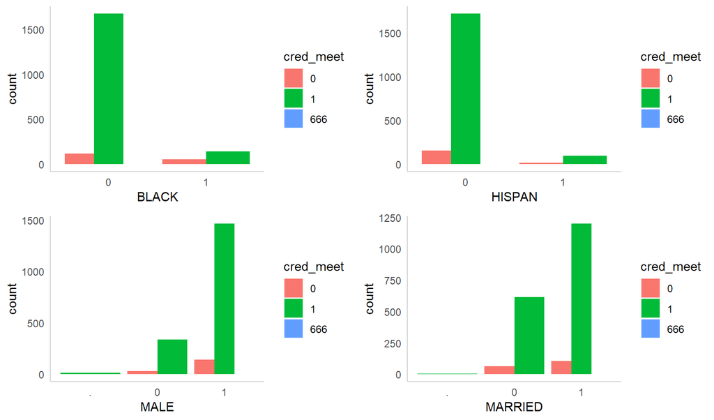

```r
# Code histograms using grid.arrange so can see all quant variables together
# Graph between each promo and its count
# Graph between each flavor and its count
# graph between each brand, its falor and count
# and vice versa
grid.arrange(
  mld_data %>%
    ggplot(aes(BLACK, fill = cred_meet)) +
      geom_bar(position = "dodge") +
       theme_minimal() +
    theme(
      panel.grid.major = element_blank(),
      panel.grid.minor = element_blank(),
    axis.line = element_line(colour = "#D3D3D3")),
  mld_data %>%
    ggplot(aes(HISPAN, fill = cred_meet)) +
      geom_bar(position = "dodge") +
       theme_minimal() +
    theme(
      panel.grid.major = element_blank(),
      panel.grid.minor = element_blank(),
    axis.line = element_line(colour = "#D3D3D3")),
  mld_data %>%
    ggplot(aes(MALE, fill = cred_meet)) +
      geom_bar(position = "dodge") +
       theme_minimal() +
    theme(
      panel.grid.major = element_blank(),
      panel.grid.minor = element_blank(),
    axis.line = element_line(colour = "#D3D3D3")),
  mld_data %>%
    ggplot(aes(MARRIED, fill = cred_meet)) +
      geom_bar(position = "dodge") +
       theme_minimal() +
    theme(
      panel.grid.major = element_blank(),
      panel.grid.minor = element_blank(),
    axis.line = element_line(colour = "#D3D3D3")),
  ncol = 2
)
```

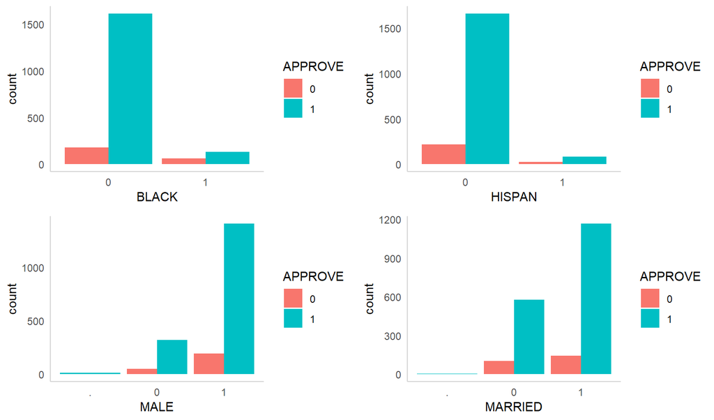

```r
# Graph between each promo and its count
# Graph between each adv and its count
# graph between each promo with adv
# and vice versa
grid.arrange(
  mld_data %>%
    ggplot(aes(BLACK, fill = APPROVE)) +
      geom_bar(position = "dodge") +
       theme_minimal() +
    theme(
      panel.grid.major = element_blank(),
      panel.grid.minor = element_blank(),
    axis.line = element_line(colour = "#D3D3D3")),
  mld_data %>%
    ggplot(aes(HISPAN, fill = APPROVE)) +
      geom_bar(position = "dodge") +
       theme_minimal() +
    theme(
      panel.grid.major = element_blank(),
      panel.grid.minor = element_blank(),
    axis.line = element_line(colour = "#D3D3D3")),
  mld_data %>%
    ggplot(aes(MALE, fill = APPROVE)) +
      geom_bar(position = "dodge") +
       theme_minimal() +
    theme(
      panel.grid.major = element_blank(),
      panel.grid.minor = element_blank(),
    axis.line = element_line(colour = "#D3D3D3")),
  mld_data %>%
    ggplot(aes(MARRIED, fill = APPROVE)) +
      geom_bar(position = "dodge") +
       theme_minimal() +
    theme(
      panel.grid.major = element_blank(),
      panel.grid.minor = element_blank(),
    axis.line = element_line(colour = "#D3D3D3")),
  ncol = 2
)
```

# 7 **Univariate non-graphical – Quantitative**

```r
# Get descrptive stats
summary(mld_data)
```

```
##  MARRIED  cred_meet    other_oblg    BLACK    HISPAN   MALE     APPROVE
##  .:   3   0  : 171   Min.   : 0.00   0:1792   0:1878   .:  15   0: 244
##  0: 678   1  :1816   1st Qu.:28.00   1: 197   1: 111   0: 369   1:1745
##  1:1308   666:   2   Median :33.00                     1:1605
##                      Mean   :32.39
##                      3rd Qu.:37.00
##                      Max.   :95.00
##     LOANPRC
##  Min.   :0.02105
##  1st Qu.:0.70000
##  Median :0.80000
##  Mean   :0.77064
##  3rd Qu.:0.89894
##  Max.   :2.57143
```

# 8 ## Univariate graphical – Quantitative

We need to look at histograms of quantitative variables to confirm what we have just seen.

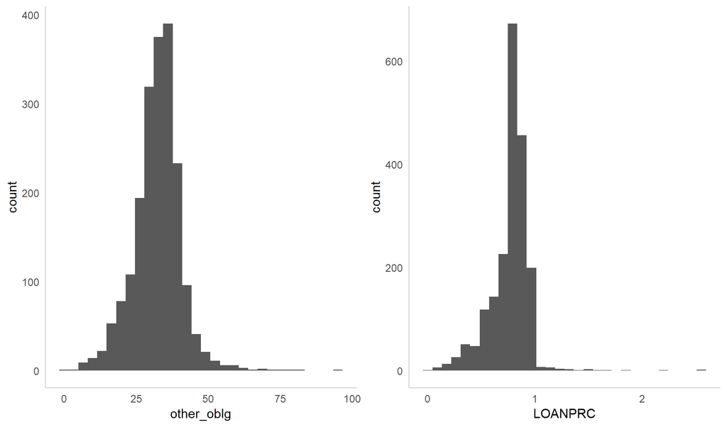

```r
# Code histograms using grid.arrange so can see all quant variables together
# histogram to see how sales, price, unit and volume is distributed in sample given
grid.arrange(
  mld_data %>%
    ggplot(aes(other_oblg)) +
      geom_histogram() +
       theme_minimal() +
    theme(
      panel.grid.major = element_blank(),
      panel.grid.minor = element_blank(),
    axis.line = element_line(colour = "#D3D3D3")),
  mld_data %>%
    ggplot(aes(LOANPRC)) +
      geom_histogram() +
       theme_minimal() +
    theme(
      panel.grid.major = element_blank(),
      panel.grid.minor = element_blank(),
    axis.line = element_line(colour = "#D3D3D3")),
  ncol = 2
)
```

**Boxplots of quantitative data**

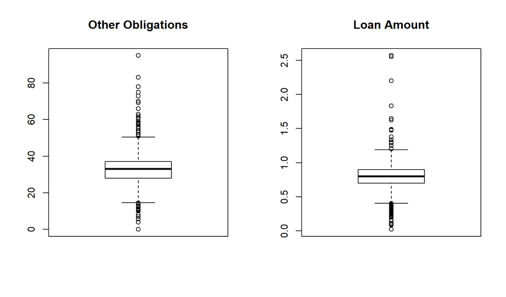

```r
# Set grid pattern for graph arrangement
# draw the box plots to see the variation in all quantitative variables : unit, price,volume, sales
par(mfrow = c(1, 2))
boxplot(mld_data$other_oblg, main = "Other Obligations")
boxplot(mld_data$LOANPRC, main = "Loan Amount")
```

# 9 Multivariate non-graphical – Categorical

Use cross-tabs for counts/proportion/percent

```r
# Proportions might be more informative
mld_data %>%
  tabyl(MARRIED, cred_meet) %>%
  adorn_totals(where = c("row", "col")) %>%
  adorn_percentages(denominator = "all") %>%
  adorn_pct_formatting(digits = 0) %>%
  kableExtra::kable() %>%
  kable_styling(full_width = FALSE)
```

| MARRIED | 0 | 1 | 666 | Total |
| --- | --- | --- | --- | --- |
| . | 0% | 0% | 0% | 0% |
| 0 | 3% | 31% | 0% | 34% |
| 1 | 5% | 60% | 0% | 66% |
| Total | 9% | 91% | 0% | 100% |

```r
# Proportions might be more informative
mld_data %>%
  tabyl(BLACK, cred_meet) %>%
  adorn_totals(where = c("row", "col")) %>%
  adorn_percentages(denominator = "all") %>%
  adorn_pct_formatting(digits = 0) %>%
  kableExtra::kable() %>%
  kable_styling(full_width = FALSE)
```

| BLACK | 0 | 1 | 666 | Total |
| --- | --- | --- | --- | --- |
| 0 | 6% | 84% | 0% | 90% |
| 1 | 3% | 7% | 0% | 10% |
| Total | 9% | 91% | 0% | 100% |

```r
# Proportions might be more informative
mld_data %>%
  tabyl(HISPAN, cred_meet) %>%
  adorn_totals(where = c("row", "col")) %>%
  adorn_percentages(denominator = "all") %>%
  adorn_pct_formatting(digits = 0) %>%
  kableExtra::kable() %>%
  kable_styling(full_width = FALSE)
```

| HISPAN | 0 | 1 | 666 | Total |
| --- | --- | --- | --- | --- |
| 0 | 8% | 87% | 0% | 94% |
| 1 | 1% | 5% | 0% | 6% |
| Total | 9% | 91% | 0% | 100% |

```r
# Proportions might be more informative
mld_data %>%
  tabyl(MALE, cred_meet) %>%
  adorn_totals(where = c("row", "col")) %>%
  adorn_percentages(denominator = "all") %>%
  adorn_pct_formatting(digits = 0) %>%
  kableExtra::kable() %>%
  kable_styling(full_width = FALSE)
```

| MALE | 0 | 1 | 666 | Total |
| --- | --- | --- | --- | --- |
| . | 0% | 1% | 0% | 1% |
| 0 | 2% | 17% | 0% | 19% |
| 1 | 7% | 74% | 0% | 81% |
| Total | 9% | 91% | 0% | 100% |

```r
# Proportions might be more informative
mld_data %>%
  tabyl(MARRIED, APPROVE) %>%
  adorn_totals(where = c("row", "col")) %>%
  adorn_percentages(denominator = "all") %>%
  adorn_pct_formatting(digits = 0) %>%
  kableExtra::kable() %>%
  kable_styling(full_width = FALSE)
```

| MARRIED | 0 | 1 | Total |
| --- | --- | --- | --- |
| . | 0% | 0% | 0% |
| 0 | 5% | 29% | 34% |
| 1 | 7% | 59% | 66% |
| Total | 12% | 88% | 100% |

```r
# Proportions might be more informative
mld_data %>%
  tabyl(BLACK, APPROVE) %>%
  adorn_totals(where = c("row", "col")) %>%
  adorn_percentages(denominator = "all") %>%
  adorn_pct_formatting(digits = 0) %>%
  kableExtra::kable() %>%
  kable_styling(full_width = FALSE)
```

| BLACK | 0 | 1 | Total |
| --- | --- | --- | --- |
| 0 | 9% | 81% | 90% |
| 1 | 3% | 7% | 10% |
| Total | 12% | 88% | 100% |

```r
# Proportions might be more informative
mld_data %>%
  tabyl(HISPAN, APPROVE) %>%
  adorn_totals(where = c("row", "col")) %>%
  adorn_percentages(denominator = "all") %>%
  adorn_pct_formatting(digits = 0) %>%
  kableExtra::kable() %>%
  kable_styling(full_width = FALSE)
```

| HISPAN | 0 | 1 | Total |
| --- | --- | --- | --- |
| 0 | 11% | 83% | 94% |
| 1 | 1% | 4% | 6% |
| Total | 12% | 88% | 100% |

```r
# Proportions might be more informative
mld_data %>%
  tabyl(MALE, APPROVE) %>%
  adorn_totals(where = c("row", "col")) %>%
  adorn_percentages(denominator = "all") %>%
  adorn_pct_formatting(digits = 0) %>%
  kableExtra::kable() %>%
  kable_styling(full_width = FALSE)
```

| MALE | 0 | 1 | Total |
| --- | --- | --- | --- |
| . | 0% | 1% | 1% |
| 0 | 3% | 16% | 19% |
| 1 | 10% | 71% | 81% |
| Total | 12% | 88% | 100% |

# 10 ## Multivariate non-graphical – Quantitative

The standard measure we can use to assess relationships is correlation.

```r
# Find correlation of quantiative variables

cor(mld_data[, c(3,8)])
```

```
##            other_oblg   LOANPRC
## other_oblg  1.0000000 0.1989376
## LOANPRC     0.1989376 1.0000000
```

# 11 Multivariate graphical code – Quantitative

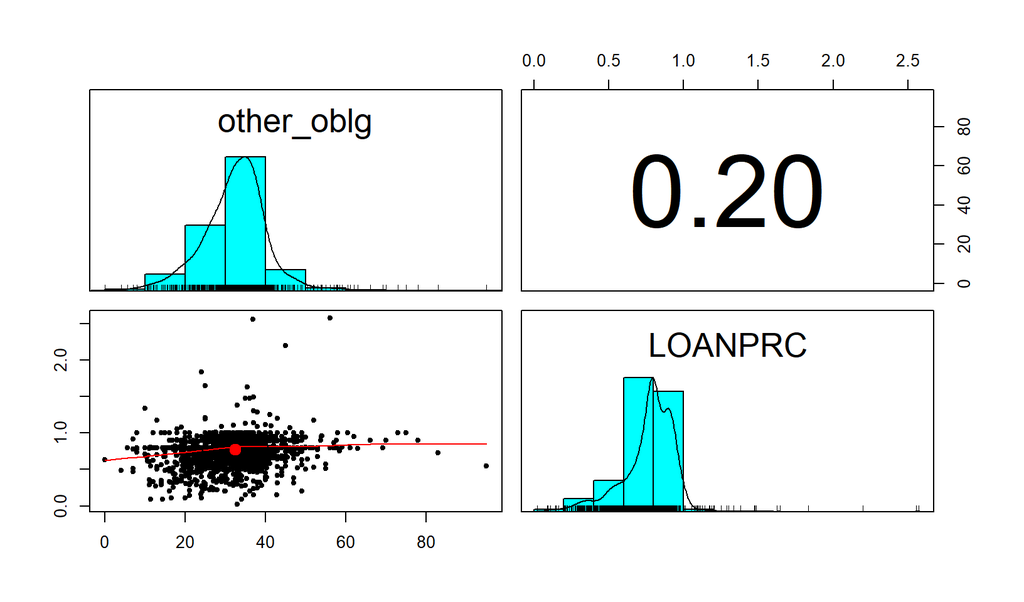

```r
# the correlation plot from the psych package -- `install.package("psych")` if not installed already

pairs.panels(mld_data[, c(3,8)])
```